# Supervised Learning - Foundations Project: ReCell

## Context

Buying and selling used phones and tablets used to be something that happened on a handful of online marketplace sites. But the used and refurbished device market has grown considerably over the past decade, and a new IDC (International Data Corporation) forecast predicts that the used phone market would be worth \$52.7bn by 2023 with a compound annual growth rate (CAGR) of 13.6% from 2018 to 2023. This growth can be attributed to an uptick in demand for used phones and tablets that offer considerable savings compared with new models.

Refurbished and used devices continue to provide cost-effective alternatives to both consumers and businesses that are looking to save money when purchasing one. There are plenty of other benefits associated with the used device market. Used and refurbished devices can be sold with warranties and can also be insured with proof of purchase. Third-party vendors/platforms, such as Verizon, Amazon, etc., provide attractive offers to customers for refurbished devices. Maximizing the longevity of devices through second-hand trade also reduces their environmental impact and helps in recycling and reducing waste. The impact of the COVID-19 outbreak may further boost this segment as consumers cut back on discretionary spending and buy phones and tablets only for immediate needs.

## Objective

The rising potential of this comparatively under-the-radar market fuels the need for an ML-based solution to develop a dynamic pricing strategy for used and refurbished devices. ReCell, a startup aiming to tap the potential in this market, has hired you as a data scientist. They want you to analyze the data provided and build a linear regression model to predict the price of a used phone/tablet and identify factors that significantly influence it.

## Data Description

The data contains the different attributes of used/refurbished phones and tablets. The data was collected in the year 2021. The detailed data dictionary is given below.

**Data Dictionary**

- brand_name: Name of manufacturing brand
- os: OS on which the device runs
- screen_size: Size of the screen in cm
- 4g: Whether 4G is available or not
- 5g: Whether 5G is available or not
- main_camera_mp: Resolution of the rear camera in megapixels
- selfie_camera_mp: Resolution of the front camera in megapixels
- int_memory: Amount of internal memory (ROM) in GB
- ram: Amount of RAM in GB
- battery: Energy capacity of the device battery in mAh
- weight: Weight of the device in grams
- release_year: Year when the device model was released
- days_used: Number of days the used/refurbished device has been used
- normalized_new_price: Normalized price of a new device of the same model in euros
- normalized_used_price: Normalized price of the used/refurbished device in euros

## Importing necessary libraries and data

```python
# import libraries for data manipulation
import numpy as np
import pandas as pd

# import libraries for data visualization
import matplotlib.pyplot as plt
import seaborn as sns
```

## Data Overview

- Observations
- Sanity checks

```python
df = pd.read_csv('used_device_data.csv')
```

```python
df.head(5)
```

|  | brand_name | os | screen_size | 4g | 5g | main_camera_mp | selfie_camera_mp | int_memory | ram | battery | weight | release_year | days_used | normalized_used_price | normalized_new_price |
| --- | --- | --- | --- | --- | --- | --- | --- | --- | --- | --- | --- | --- | --- | --- | --- |
| 0 | Honor | Android | 14.50 | yes | no | 13.0 | 5.0 | 64.0 | 3.0 | 3020.0 | 146.0 | 2020 | 127 | 4.307572 | 4.715100 |
| 1 | Honor | Android | 17.30 | yes | yes | 13.0 | 16.0 | 128.0 | 8.0 | 4300.0 | 213.0 | 2020 | 325 | 5.162097 | 5.519018 |
| 2 | Honor | Android | 16.69 | yes | yes | 13.0 | 8.0 | 128.0 | 8.0 | 4200.0 | 213.0 | 2020 | 162 | 5.111084 | 5.884631 |
| 3 | Honor | Android | 25.50 | yes | yes | 13.0 | 8.0 | 64.0 | 6.0 | 7250.0 | 480.0 | 2020 | 345 | 5.135387 | 5.630961 |
| 4 | Honor | Android | 15.32 | yes | no | 13.0 | 8.0 | 64.0 | 3.0 | 5000.0 | 185.0 | 2020 | 293 | 4.389995 | 4.947837 |

```python
num_of_rows, num_of_columns = df.shape
print(fr'''
Number of rows in the dataframe: {num_of_rows}
Number of columns in the dataframe: {num_of_columns}
''')
```

```
Number of rows in the dataframe: 3454
Number of columns in the dataframe: 15
```

**The data has 15 columns with 3454 rows**

```python
df.info()
```

```
<class 'pandas.core.frame.DataFrame'>
RangeIndex: 3454 entries, 0 to 3453
Data columns (total 15 columns):
 #   Column                 Non-Null Count  Dtype
---  ------                 --------------  -----
 0   brand_name             3454 non-null   object
 1   os                     3454 non-null   object
 2   screen_size            3454 non-null   float64
 3   4g                     3454 non-null   object
 4   5g                     3454 non-null   object
 5   main_camera_mp         3275 non-null   float64
 6   selfie_camera_mp       3452 non-null   float64
 7   int_memory             3450 non-null   float64
 8   ram                    3450 non-null   float64
 9   battery                3448 non-null   float64
 10  weight                 3447 non-null   float64
 11  release_year           3454 non-null   int64
 12  days_used              3454 non-null   int64
 13  normalized_used_price  3454 non-null   float64
 14  normalized_new_price   3454 non-null   float64
dtypes: float64(9), int64(2), object(4)
memory usage: 404.9+ KB
```

**brand_name, os, 4g, and 5g all have the object datatype. The remaining variables have a numeric datatype**

```python
num_of_rows = df.shape[0]
num_of_missing_values = df.isna().sum().sum()
print(fr'Dataset contains {num_of_rows} rows.')
print(fr'Dataset contains {num_of_missing_values} missing values.')
```

```
Dataset contains 3454 rows.
Dataset contains 202 missing values.
```

**There are 202 missing values in total.**

```python
df.isna().sum()
```

```
brand_name                 0
os                         0
screen_size                0
4g                         0
5g                         0
main_camera_mp           179
selfie_camera_mp           2
int_memory                 4
ram                        4
battery                    6
weight                     7
release_year               0
days_used                  0
normalized_used_price      0
normalized_new_price       0
dtype: int64
```

**All the missing values are contained in main_camera_mp, selfie_camera_mp, int_memory, ram, battery, and weight.**

```python
df.nunique()
```

```
brand_name                 34
os                          4
screen_size               142
4g                          2
5g                          2
main_camera_mp             41
selfie_camera_mp           37
int_memory                 15
ram                        12
battery                   324
weight                    555
release_year                8
days_used                 924
normalized_used_price    3094
normalized_new_price     2988
dtype: int64
```

**There are 4, 2, 2, and 8 unique values for os, 4g, 5g, and release year, respectively.**  
**There are a dozen to several dozen unique values for brand_name, main_camera_mp, selfie_camera_mp, int_memory, ram.**  
**There are a hundred to several hundred unique values for screen_size, battery, weight, and days_used.**  
**There are several thousand unique values for normalized_used_price and normalized_new_price.**

```python
df.describe()
```

|  | screen_size | main_camera_mp | selfie_camera_mp | int_memory | ram | battery | weight | release_year | days_used | normalized_used_price | normalized_new_price |
| --- | --- | --- | --- | --- | --- | --- | --- | --- | --- | --- | --- |
| count | 3454.000000 | 3275.000000 | 3452.000000 | 3450.000000 | 3450.000000 | 3448.000000 | 3447.000000 | 3454.000000 | 3454.000000 | 3454.000000 | 3454.000000 |
| mean | 13.713115 | 9.460208 | 6.554229 | 54.573099 | 4.036122 | 3133.402697 | 182.751871 | 2015.965258 | 674.869716 | 4.364712 | 5.233107 |
| std | 3.805280 | 4.815461 | 6.970372 | 84.972371 | 1.365105 | 1299.682844 | 88.413228 | 2.298455 | 248.580166 | 0.588914 | 0.683637 |
| min | 5.080000 | 0.080000 | 0.000000 | 0.010000 | 0.020000 | 500.000000 | 69.000000 | 2013.000000 | 91.000000 | 1.536867 | 2.901422 |
| 25% | 12.700000 | 5.000000 | 2.000000 | 16.000000 | 4.000000 | 2100.000000 | 142.000000 | 2014.000000 | 533.500000 | 4.033931 | 4.790342 |
| 50% | 12.830000 | 8.000000 | 5.000000 | 32.000000 | 4.000000 | 3000.000000 | 160.000000 | 2015.500000 | 690.500000 | 4.405133 | 5.245892 |
| 75% | 15.340000 | 13.000000 | 8.000000 | 64.000000 | 4.000000 | 4000.000000 | 185.000000 | 2018.000000 | 868.750000 | 4.755700 | 5.673718 |
| max | 30.710000 | 48.000000 | 32.000000 | 1024.000000 | 12.000000 | 9720.000000 | 855.000000 | 2020.000000 | 1094.000000 | 6.619433 | 7.847841 |

```python
df['brand_name'].value_counts()
```

```
Others        502
Samsung       341
Huawei        251
LG            201
Lenovo        171
ZTE           140
Xiaomi        132
Oppo          129
Asus          122
Alcatel       121
Vivo          117
Micromax      117
Honor         116
HTC           110
Motorola      106
Nokia         106
Sony           86
Meizu          62
Gionee         56
Acer           51
XOLO           49
Panasonic      47
Realme         41
Apple          39
Lava           36
Celkon         33
Spice          30
Karbonn        29
BlackBerry     22
Microsoft      22
OnePlus        22
Coolpad        22
Google         15
Infinix        10
Name: brand_name, dtype: int64
```

```python
df['os'].value_counts()
```

```
Android    3214
Others      137
Windows      67
iOS          36
Name: os, dtype: int64
```

```python
df['4g'].value_counts()
```

```
yes    2335
no     1119
Name: 4g, dtype: int64
```

```python
df['5g'].value_counts()
```

```
no     3302
yes     152
Name: 5g, dtype: int64
```

## Exploratory Data Analysis (EDA)

- EDA is an important part of any project involving data.
- It is important to investigate and understand the data better before building a model with it.
- A few questions have been mentioned below which will help you approach the analysis in the right manner and generate insights from the data.
- A thorough analysis of the data, in addition to the questions mentioned below, should be done.

**Questions**:

1. What does the distribution of normalized used device prices look like?
2. What percentage of the used device market is dominated by Android devices?
3. The amount of RAM is important for the smooth functioning of a device. How does the amount of RAM vary with the brand?
4. A large battery often increases a device's weight, making it feel uncomfortable in the hands. How does the weight vary for phones and tablets offering large batteries (more than 4500 mAh)?
5. Bigger screens are desirable for entertainment purposes as they offer a better viewing experience. How many phones and tablets are available across different brands with a screen size larger than 6 inches?
6. A lot of devices nowadays offer great selfie cameras, allowing us to capture our favorite moments with loved ones. What is the distribution of devices offering greater than 8MP selfie cameras across brands?
7. Which attributes are highly correlated with the normalized price of a used device?

**1. What does the distribution of normalized used device prices look like?**

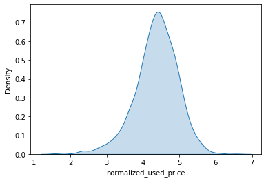

```python
sns.kdeplot(data = df, x = 'normalized_used_price', shade = 'fill')
```

```python
print(df['normalized_used_price'].mean())
print(df['normalized_used_price'].std())
```

```
4.364712079133223
0.5889136178484657
```

```python
from scipy.stats import skew, kurtosis
```

```python
print(skew(df['normalized_used_price']))
```

```
-0.5321066064150582
```

```python
print(kurtosis(df['normalized_used_price']))
```

```
1.175385016911422
```

**2. What percentage of the used device market is dominated by Android devices?**

```python
df['os'].unique()
```

```
array(['Android', 'Others', 'iOS', 'Windows'], dtype=object)
```

```python
df['os'].value_counts()
```

```
Android    3214
Others      137
Windows      67
iOS          36
Name: os, dtype: int64
```

```python
android_market_share = df['os'].value_counts()['Android'] / df['os'].value_counts().sum() * 100
```

```python
print(fr'''Android makes up {round(android_market_share, 2)}% of the used device market.''')
```

```
Android makes up 93.05% of the used device market.
```

**Android makes up 93.05% of the used device market.**

**3. The amount of RAM is important for the smooth functioning of a device. How does the amount of RAM vary with the brand?**

```python
df['ram'].unique()
```

```
array([ 3.  ,  8.  ,  6.  ,  4.  ,  2.  ,  1.  , 12.  ,  0.5 ,  0.25,
        0.03,   nan,  0.02,  1.5 ])
```

```python
df['brand_name'].unique()
```

```
array(['Honor', 'Others', 'HTC', 'Huawei', 'Infinix', 'Lava', 'Lenovo',
       'LG', 'Meizu', 'Micromax', 'Motorola', 'Nokia', 'OnePlus', 'Oppo',
       'Realme', 'Samsung', 'Vivo', 'Xiaomi', 'ZTE', 'Apple', 'Asus',
       'Coolpad', 'Acer', 'Alcatel', 'BlackBerry', 'Celkon', 'Gionee',
       'Google', 'Karbonn', 'Microsoft', 'Panasonic', 'Sony', 'Spice',
       'XOLO'], dtype=object)
```

```python
df_ram = df.copy()[['ram', 'brand_name']]
```

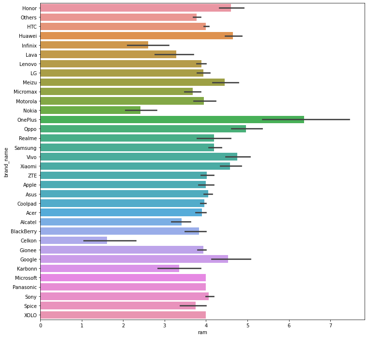

```python
plt.figure(figsize=(12, 12))
sns.barplot(data = df_ram, x = 'ram', y = 'brand_name')
```

**OnePlus has the largest average amount of RAM.**  
**Celkon, Nokia, and Infinix have a relatively small amount of RAM, with Celkon having the smallest amount of RAM.**  
**All other phone brands have similar amounts of RAM on average.**

**4. A large battery often increases a device's weight, making it feel uncomfortable in the hands. How does the weight vary for phones and tablets offering large batteries (more than 4500 mAh)?**

```python
df_battery = df.copy()
```

```python
df_battery['battery_flag'] = 0
```

```python
df_battery.loc[df_battery['battery'] > 4500, 'battery_flag'] = 1
```

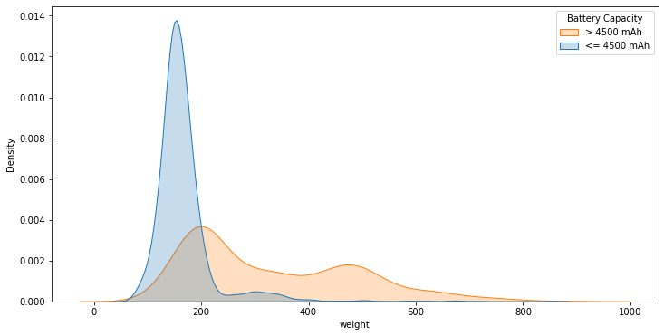

```python
plt.figure(figsize=(12, 6))
sns.kdeplot(data = df_battery, x = 'weight', hue = 'battery_flag', shade = 'fill', common_norm = False)
plt.legend(title = 'Battery Capacity', loc = 'upper right', labels = ['> 4500 mAh', '<= 4500 mAh'])
```

**Batteries with a higher battery capacity have a larger range (larger standard deviation) of weights.**  
**Batteries with a higher battery capacity follow a heavy right-tail distribution with a maxima at approximately 200 and a local maxima at approximately 480.**

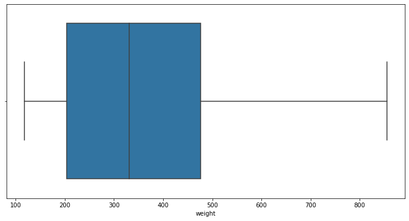

```python
plt.figure(figsize=(12, 6))
sns.boxplot(data = df_battery.where(df_battery['battery_flag'] == 1).dropna(), x = 'weight')
```

**Batteries with capacities greater than 4500 mAh have a 25th percentile of weight of 200 and a 75th percentile of weight of approximately 480.**

**5. Bigger screens are desirable for entertainment purposes as they offer a better viewing experience. How many phones and tablets are available across different brands with a screen size larger than 6 inches?**

```python
df_screen = df.where(df['screen_size'] > 6).dropna()[['screen_size', 'brand_name']]
```

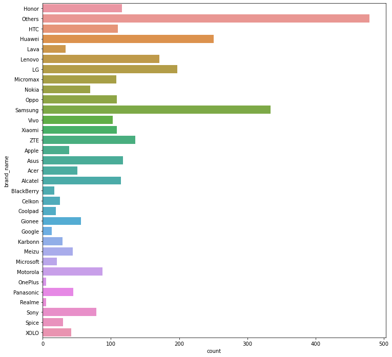

```python
plt.figure(figsize=(12, 12))
sns.countplot(data = df_screen, y = 'brand_name')
```

**6. A lot of devices nowadays offer great selfie cameras, allowing us to capture our favorite moments with loved ones. What is the distribution of devices offering greater than 8MP selfie cameras across brands?**

```python
df_selfie = df.where(df['selfie_camera_mp'] > 8).dropna()[['selfie_camera_mp', 'brand_name']]
```

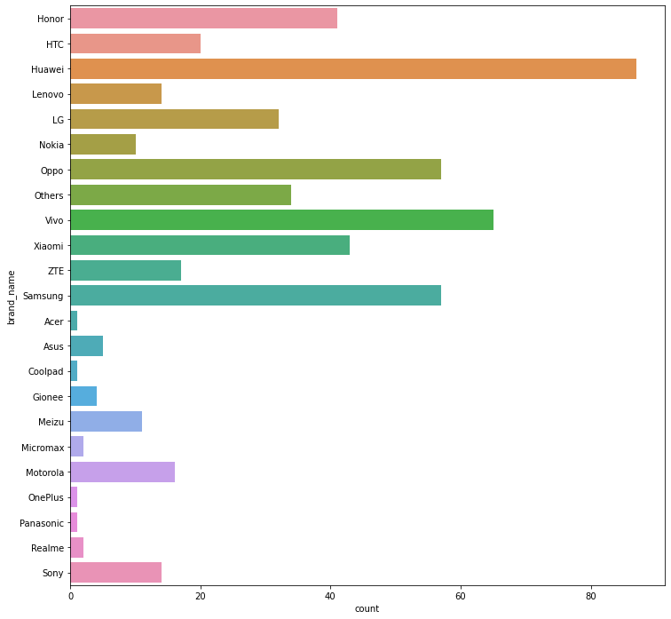

```python
plt.figure(figsize=(12, 12))
sns.countplot(data = df_selfie, y = 'brand_name')
```

**7. Which attributes are highly correlated with the normalized price of a used device?**

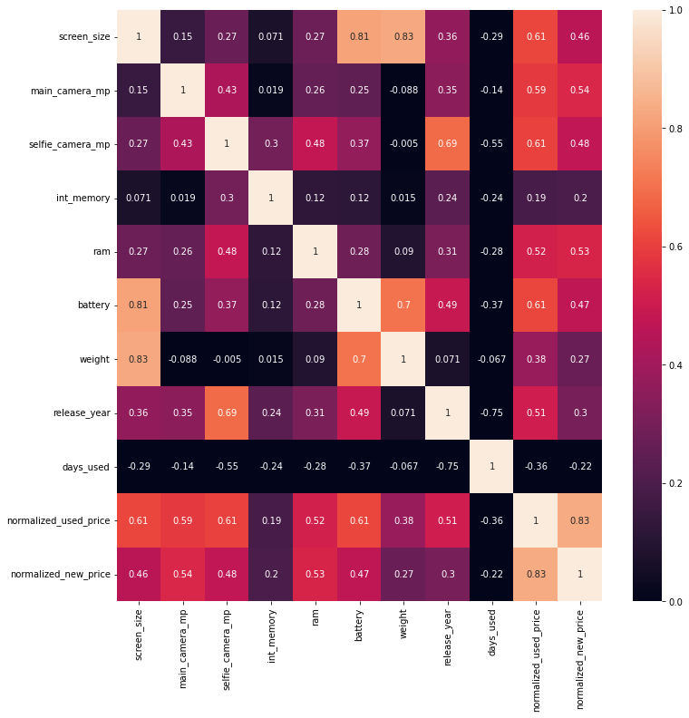

```python
plt.figure(figsize=(12, 12))
ax = sns.heatmap(data = df.corr(), vmin = 0, vmax = 1, annot = True)
```

**Calculate the variance inflation factor of the dataset.**

```python
from statsmodels.stats.outliers_influence import variance_inflation_factor
```

```python
features = [
    'screen_size',
    'main_camera_mp',
    'selfie_camera_mp',
    'int_memory',
    'ram',
    'battery',
    'weight',
    'release_year',
    'days_used',
    'normalized_new_price',
]
```

```python
df_vif = df.copy()[features]
```

```python
df_vif.dropna(inplace = True)
```

```python
vif = [
    [val, variance_inflation_factor(df_vif.values, i)]
    for i, val
    in zip(np.arange(0, len(df_vif.columns)), df_vif.columns.values)
]
```

```python
vif_score_df = pd.DataFrame(vif, columns = ['Feature', 'VIF']).sort_values(by = 'VIF')
```

```python
print(vif_score_df)
```

```
                Feature         VIF
3            int_memory    1.548655
2      selfie_camera_mp    3.805148
1        main_camera_mp    8.641831
8             days_used   14.857852
4                   ram   16.777768
5               battery   23.957722
6                weight   25.247683
0           screen_size   76.368021
7          release_year   94.741134
9  normalized_new_price  136.113101
```

**This result of variance inflation factor indicates there is a high degree of multicolinearity in the dataset.**  
**This level of multicolinearity is dangerous and can degrade the performance of a prediction model.**

## Data Preprocessing

- Missing value treatment
- Feature engineering (if needed)
- Outlier detection and treatment (if needed)
- Preparing data for modeling
- Any other preprocessing steps (if needed)

**1. Missing value treatment**

```python
df.isna().sum()
```

```
brand_name                 0
os                         0
screen_size                0
4g                         0
5g                         0
main_camera_mp           179
selfie_camera_mp           2
int_memory                 4
ram                        4
battery                    6
weight                     7
release_year               0
days_used                  0
normalized_used_price      0
normalized_new_price       0
dtype: int64
```

**main_camera_mp has 179 NaN values. It is possible that this means that the camera does not exist.**  
**Determine if it is okay to impute a 0 for when main_camera_mp is NaN.**

```python
df['main_camera_mp'].value_counts(dropna = False)
```

```
13.00    1035
8.00      755
5.00      546
12.00     189
NaN       179
2.00      171
16.00     154
3.15      122
0.30       69
10.50      30
1.30       26
21.00      19
23.00      19
20.70      16
20.00      13
14.50      13
12.20      12
4.00       10
12.30       9
19.00       8
8.10        7
13.10       6
10.00       6
3.00        5
24.00       5
48.00       4
6.70        4
12.50       4
6.50        4
21.20       2
1.00        1
18.00       1
22.60       1
0.08        1
20.10       1
16.30       1
1.20        1
41.00       1
21.50       1
22.50       1
20.20       1
12.60       1
Name: main_camera_mp, dtype: int64
```

**No zero value is provided in the value counts. It appears to be okay to impute zero for NaN values.**

```python
df.loc[df['main_camera_mp'].isna(), 'main_camera_mp'] = 0.0
```

```python
df['main_camera_mp'].value_counts(dropna = False)
```

```
13.00    1035
8.00      755
5.00      546
12.00     189
0.00      179
2.00      171
16.00     154
3.15      122
0.30       69
10.50      30
1.30       26
21.00      19
23.00      19
20.70      16
20.00      13
14.50      13
12.20      12
4.00       10
12.30       9
19.00       8
8.10        7
13.10       6
10.00       6
3.00        5
24.00       5
48.00       4
6.70        4
12.50       4
6.50        4
21.20       2
1.00        1
18.00       1
22.60       1
0.08        1
20.10       1
16.30       1
1.20        1
41.00       1
21.50       1
22.50       1
20.20       1
12.60       1
Name: main_camera_mp, dtype: int64
```

**The NaN values have been imputed with 0.0.**

```python
df.isna().sum()
```

```
brand_name               0
os                       0
screen_size              0
4g                       0
5g                       0
main_camera_mp           0
selfie_camera_mp         2
int_memory               4
ram                      4
battery                  6
weight                   7
release_year             0
days_used                0
normalized_used_price    0
normalized_new_price     0
dtype: int64
```

**Determine if NaN values of selfie_camera_mp can be imputed as 0.0.**

```python
df['selfie_camera_mp'].value_counts(dropna = False)
```

```
5.00     791
8.00     549
2.00     538
0.30     492
16.00    298
1.30     148
32.00     94
13.00     90
20.00     67
1.20      43
0.00      39
2.10      37
1.00      34
1.60      31
24.00     30
25.00     28
12.00     21
7.00      21
4.00      20
1.90      12
2.20      11
10.00     10
5.10       9
3.00       7
1.10       5
14.50      5
9.00       4
14.00      3
3.70       3
NaN        2
0.65       2
18.00      2
1.25       2
10.50      2
3.50       1
16.30      1
0.90       1
1.80       1
Name: selfie_camera_mp, dtype: int64
```

**It seems that 0.0 values are present in the dataset. Because of this and the small quantity of NaN values, it is better to drop them.**

**Go ahead and drop all NaN values.**

```python
df.dropna(inplace = True)
```

**The NaN values have been removed.**

```python
df.isna().sum()
```

```
brand_name               0
os                       0
screen_size              0
4g                       0
5g                       0
main_camera_mp           0
selfie_camera_mp         0
int_memory               0
ram                      0
battery                  0
weight                   0
release_year             0
days_used                0
normalized_used_price    0
normalized_new_price     0
dtype: int64
```

**2. Feature engineering (if needed)**

**Work on scaling data into a normal distribution from approximately 0 to 1.**

```python
df.dtypes
```

```
brand_name                object
os                        object
screen_size              float64
4g                        object
5g                        object
main_camera_mp           float64
selfie_camera_mp         float64
int_memory               float64
ram                      float64
battery                  float64
weight                   float64
release_year               int64
days_used                  int64
normalized_used_price    float64
normalized_new_price     float64
dtype: object
```

**Feature engineer all numeric fields.**

**Perform feature engineering on screen_size.**

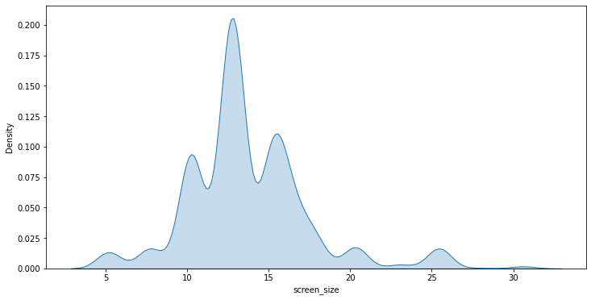

```python
plt.figure(figsize=(12, 6))
sns.kdeplot(data = df, x = 'screen_size', shade = 'fill')
```

```python
df['screen_size'] -= np.min(df['screen_size'])
df['screen_size'] /= np.max(df['screen_size'])
```

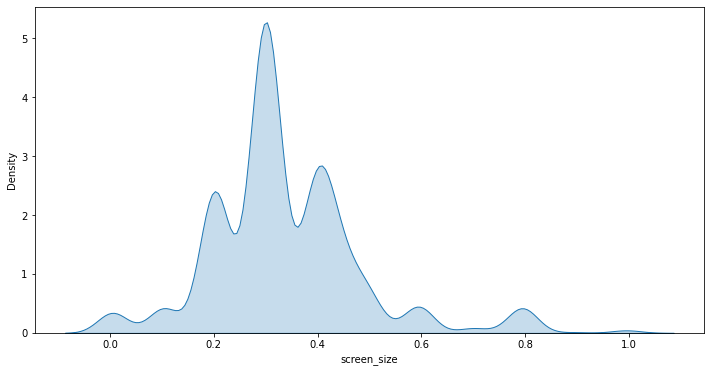

```python
plt.figure(figsize=(12, 6))
sns.kdeplot(data = df, x = 'screen_size', shade = 'fill')
```

**The data is now minmax scaled. Used nth root scaling to reduce right-skewness.**

```python
df['screen_size'].describe()
```

```
count    3432.000000
mean        0.337639
std         0.147827
min         0.000000
25%         0.297308
50%         0.302380
75%         0.401483
max         1.000000
Name: screen_size, dtype: float64
```

```python
df['screen_size'] = np.power(df['screen_size'], 2/3)
```

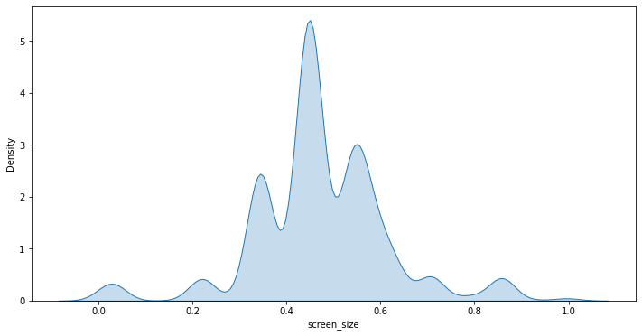

```python
plt.figure(figsize=(12, 6))
sns.kdeplot(data = df, x = 'screen_size', shade = 'fill')
```

```python
df['screen_size'].describe()
```

```
count    3432.000000
mean        0.473487
std         0.144325
min         0.000000
25%         0.445455
50%         0.450508
75%         0.544224
max         1.000000
Name: screen_size, dtype: float64
```

**Scale main_camera_mp**

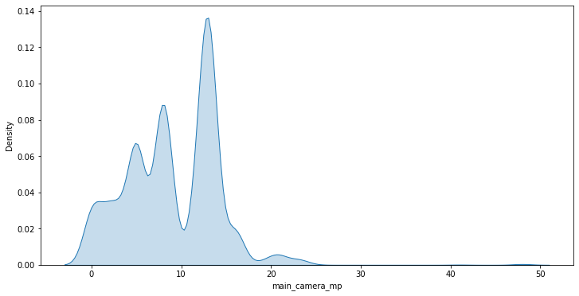

```python
plt.figure(figsize=(12, 6))
sns.kdeplot(data = df, x = 'main_camera_mp', shade = 'fill')
```

```python
df['main_camera_mp'] -= np.min(df['main_camera_mp'])
df['main_camera_mp'] /= np.max(df['main_camera_mp'])
```

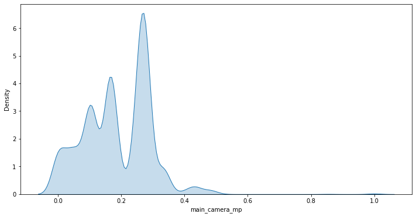

```python
plt.figure(figsize=(12, 6))
sns.kdeplot(data = df, x = 'main_camera_mp', shade = 'fill')
```

**Data is scaled. Now translate the data to the right.**

```python
df['main_camera_mp'].describe()
```

```
count    3432.000000
mean        0.187127
std         0.106838
min         0.000000
25%         0.104167
50%         0.166667
75%         0.270833
max         1.000000
Name: main_camera_mp, dtype: float64
```

**Translate data to the right such that then mean is 0.5.**

```python
df['main_camera_mp'] = df['main_camera_mp'] + 0.33
```

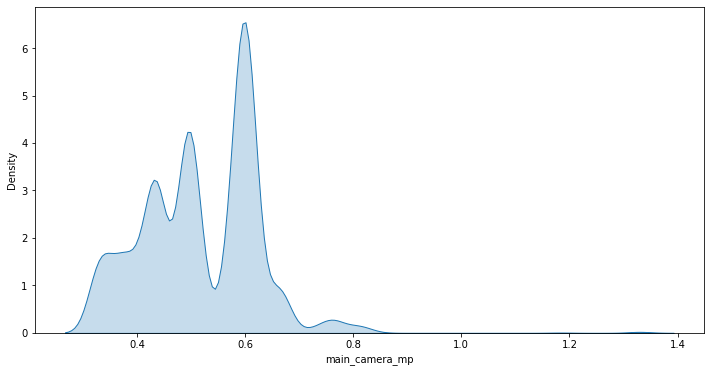

```python
plt.figure(figsize=(12, 6))
sns.kdeplot(data = df, x = 'main_camera_mp', shade = 'fill')
```

**Perform outlier treatment by imputing values greater than 1 as 1.**

```python
df.loc[df['main_camera_mp'] > 1,  'main_camera_mp'] = 1
```

[output not shown]

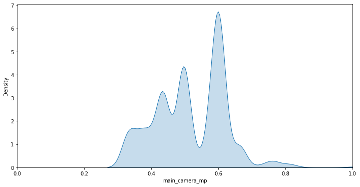

```python
plt.figure(figsize=(12, 6))
sns.kdeplot(data = df, x = 'main_camera_mp', shade = 'fill')
plt.xlim(0, 1)
```

**Perform feature engineering on selfie_camera_mp**

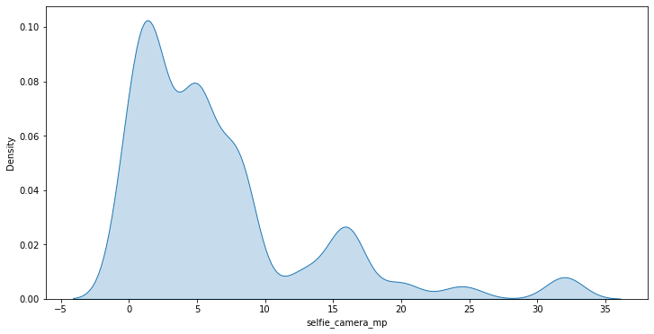

```python
plt.figure(figsize=(12, 6))
sns.kdeplot(data = df, x = 'selfie_camera_mp', shade = 'fill')
```

**Perform minmax scaling.**

```python
df['selfie_camera_mp'] -= np.min(df['selfie_camera_mp'])
df['selfie_camera_mp'] /= np.max(df['selfie_camera_mp'])
```

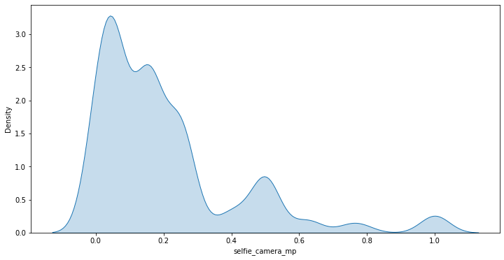

```python
plt.figure(figsize=(12, 6))
sns.kdeplot(data = df, x = 'selfie_camera_mp', shade = 'fill')
```

**Data is severely right-skewed. Use power scaling to reduce the skewness.**

```python
df['selfie_camera_mp'] = np.power(df['selfie_camera_mp'], 2/5)
```

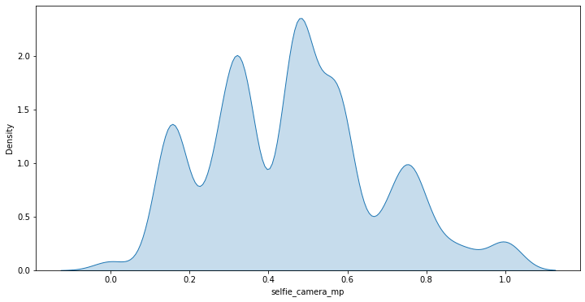

```python
plt.figure(figsize=(12, 6))
sns.kdeplot(data = df, x = 'selfie_camera_mp', shade = 'fill')
```

**Perform feature engineering on int_memory.**

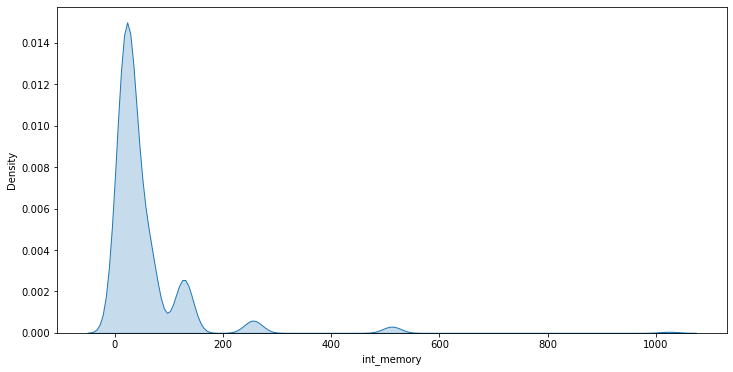

```python
plt.figure(figsize=(12, 6))
sns.kdeplot(data = df, x = 'int_memory', shade = 'fill')
```

**Use minmax scaling to reduce the data range.**

```python
df['int_memory'] -= np.min(df['int_memory'])
df['int_memory'] /= np.max(df['int_memory'])
```

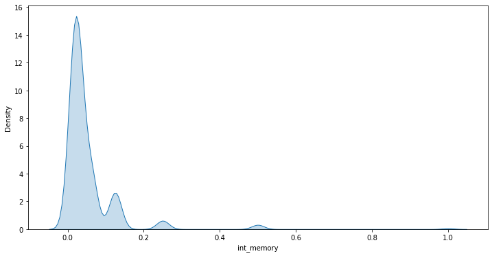

```python
plt.figure(figsize=(12, 6))
sns.kdeplot(data = df, x = 'int_memory', shade = 'fill')
```

**Translate data to the right.**

```python
df['int_memory'].describe()
```

```
count    3432.000000
mean        0.053450
std         0.083156
min         0.000000
25%         0.015615
50%         0.031241
75%         0.062491
max         1.000000
Name: int_memory, dtype: float64
```

```python
df['int_memory'] = df['int_memory'] + 0.48
```

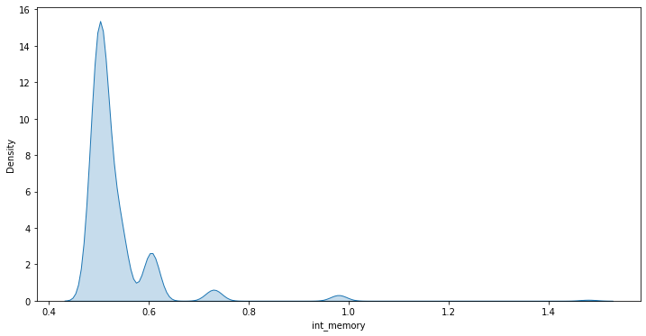

```python
plt.figure(figsize=(12, 6))
sns.kdeplot(data = df, x = 'int_memory', shade = 'fill')
```

**Impute values greater than 0.8 as 0.8.**

```python
df.loc[df['int_memory'] > 0.8,  'int_memory'] = 0.8
```

[output not shown]

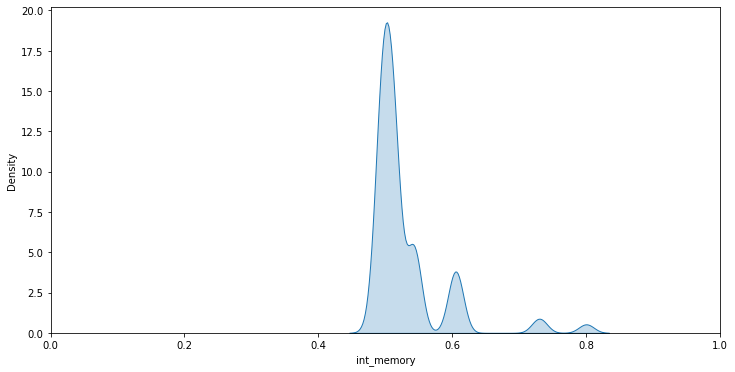

```python
plt.figure(figsize=(12, 6))
sns.kdeplot(data = df, x = 'int_memory', shade = 'fill')
plt.xlim(0, 1)
```

**Perform feature engineering on ram**

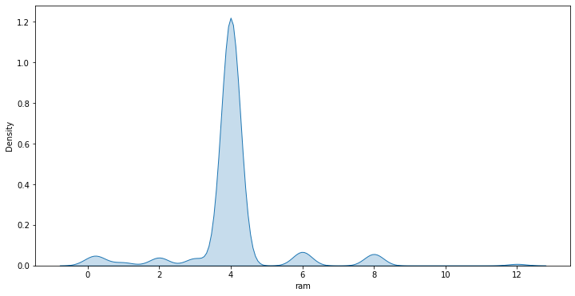

```python
plt.figure(figsize=(12, 6))
sns.kdeplot(data = df, x = 'ram', shade = 'fill')
```

**Perform minmax scaling.**

```python
df['ram'] -= np.min(df['ram'])
df['ram'] /= np.max(df['ram'])
```

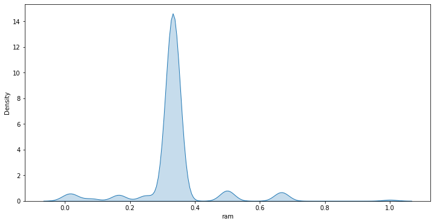

```python
plt.figure(figsize=(12, 6))
sns.kdeplot(data = df, x = 'ram', shade = 'fill')
```

**Shift values to the right.**

```python
df['ram'].describe()
```

```
count    3432.000000
mean        0.335735
std         0.113528
min         0.000000
25%         0.332220
50%         0.332220
75%         0.332220
max         1.000000
Name: ram, dtype: float64
```

```python
df['ram'] = df['ram'] + 0.17
```

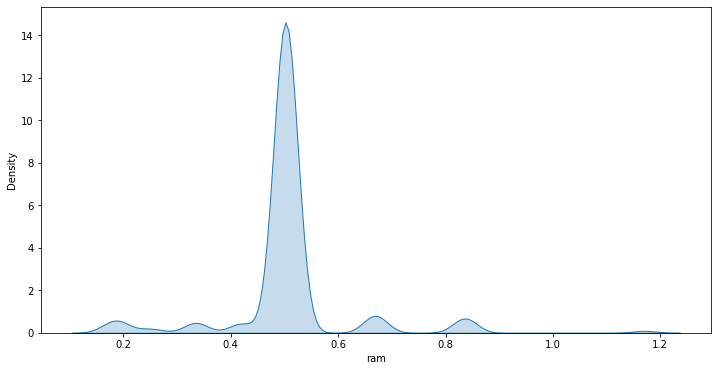

```python
plt.figure(figsize=(12, 6))
sns.kdeplot(data = df, x = 'ram', shade = 'fill')
```

**Impute values greater than 1 as 1.**

```python
df.loc[df['ram'] > 1,  'ram'] = 1
```

[output not shown]

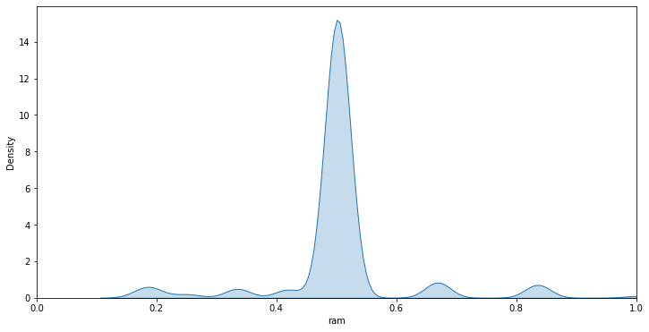

```python
plt.figure(figsize=(12, 6))
sns.kdeplot(data = df, x = 'ram', shade = 'fill')
plt.xlim(0, 1)
```

**Perform feature engineering on battery.**

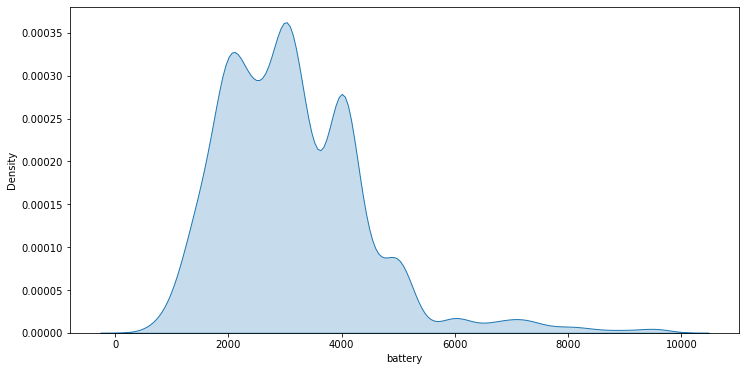

```python
plt.figure(figsize=(12, 6))
sns.kdeplot(data = df, x = 'battery', shade = 'fill')
```

```python
df['battery'] -= np.min(df['battery'])
df['battery'] /= np.max(df['battery'])
```

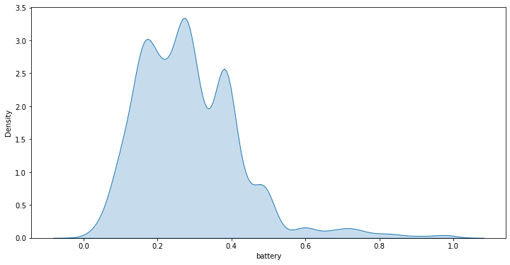

```python
plt.figure(figsize=(12, 6))
sns.kdeplot(data = df, x = 'battery', shade = 'fill')
```

**Use power scaling to reduce right-skewness.**

```python
df['battery'] = np.power(df['battery'], 1/2)
```

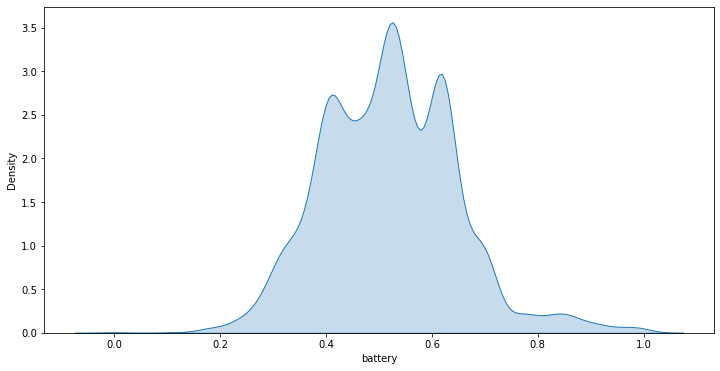

```python
plt.figure(figsize=(12, 6))
sns.kdeplot(data = df, x = 'battery', shade = 'fill')
```

**Perform feature engineering on weight**

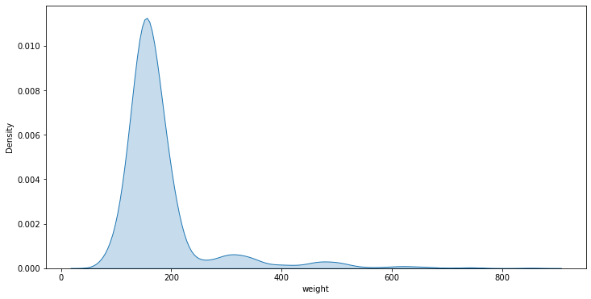

```python
plt.figure(figsize=(12, 6))
sns.kdeplot(data = df, x = 'weight', shade = 'fill')
```

```python
df['weight'] -= np.min(df['weight'])
df['weight'] /= np.max(df['weight'])
```

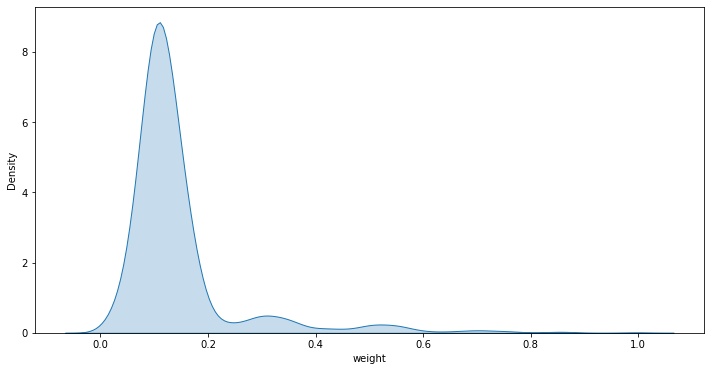

```python
plt.figure(figsize=(12, 6))
sns.kdeplot(data = df, x = 'weight', shade = 'fill')
```

**Reduce the right-skewness.**

```python
df['weight'] = np.power(df['weight'], 1/3)
```

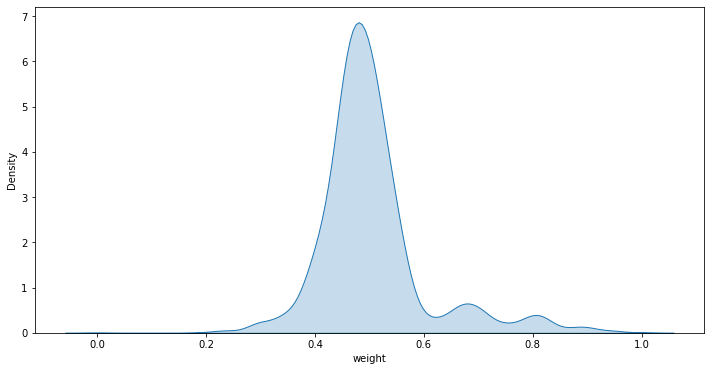

```python
plt.figure(figsize=(12, 6))
sns.kdeplot(data = df, x = 'weight', shade = 'fill')
```

**Perform feature engineering on normalized_new_price.**

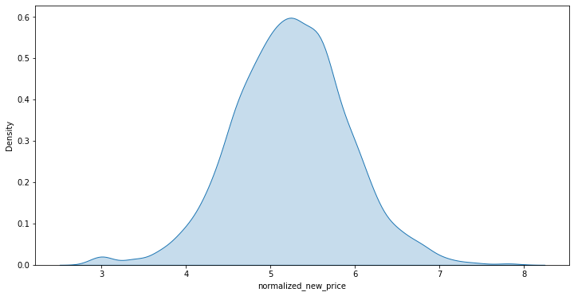

```python
plt.figure(figsize=(12, 6))
sns.kdeplot(data = df, x = 'normalized_new_price', shade = 'fill')
```

**Perform minmax scaling.**

```python
df['normalized_new_price'] -= np.min(df['normalized_new_price'])
df['normalized_new_price'] /= np.max(df['normalized_new_price'])
```

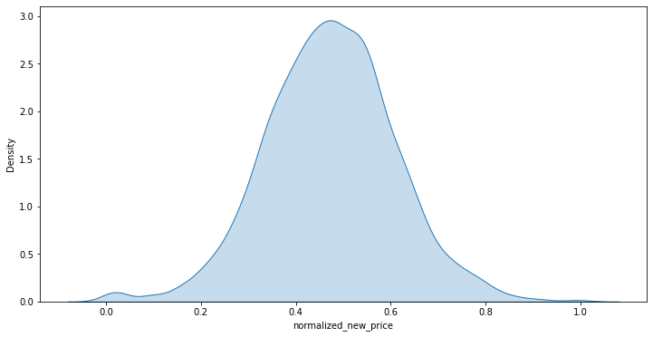

```python
plt.figure(figsize=(12, 6))
sns.kdeplot(data = df, x = 'normalized_new_price', shade = 'fill')
```

**Perform feature engineering on days_used**

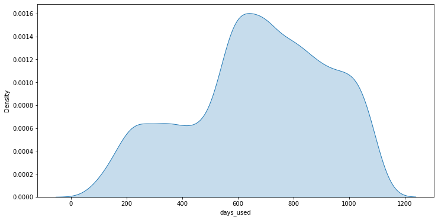

```python
plt.figure(figsize=(12, 6))
sns.kdeplot(data = df, x = 'days_used', shade = 'fill')
```

**Perform minmax scaling.**

```python
df['days_used'] -= np.min(df['days_used'])
df['days_used'] /= np.max(df['days_used'])
```

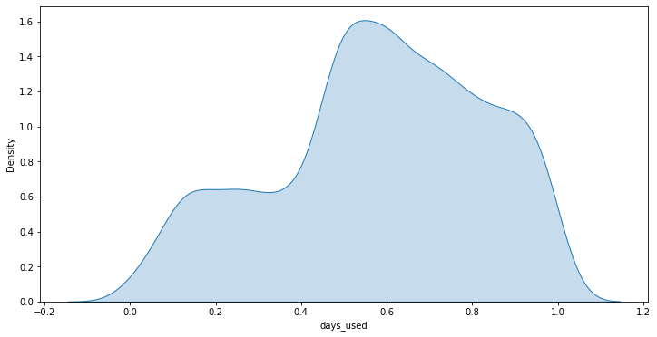

```python
plt.figure(figsize=(12, 6))
sns.kdeplot(data = df, x = 'days_used', shade = 'fill')
```

**Perform feature engineering on release_year**

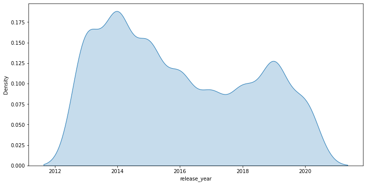

```python
plt.figure(figsize=(12, 6))
sns.kdeplot(data = df, x = 'release_year', shade = 'fill')
```

```python
df['release_year'] -= np.min(df['release_year'])
df['release_year'] /= np.max(df['release_year'])
```

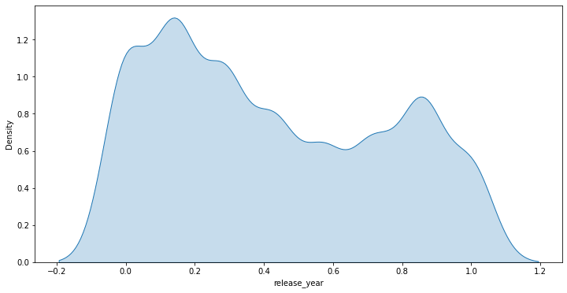

```python
plt.figure(figsize=(12, 6))
sns.kdeplot(data = df, x = 'release_year', shade = 'fill')
```

```python
df['release_year'].describe()
```

```
count    3432.000000
mean        0.423785
std         0.328455
min         0.000000
25%         0.142857
50%         0.428571
75%         0.714286
max         1.000000
Name: release_year, dtype: float64
```

**Feature engineering complete for release_year.**  
**It appears that release_year follows a bimodal distribution.**

**Feature engineering on 4g**

```python
print(df['4g'].unique())
```

```
['yes' 'no']
```

```python
df.loc[df['4g'] == 'no', '4g'] = 0
```

```python
df.loc[df['4g'] == 'yes', '4g'] = 1
```

```python
df['4g'] = df['4g'].astype(int)
```

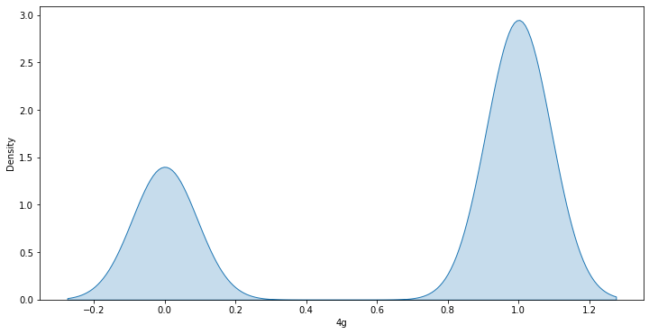

```python
plt.figure(figsize=(12, 6))
sns.kdeplot(data = df, x = '4g', shade = 'fill')
```

**Converted the categorical 4g variable to numerical.**

**Feature engineering on 5g**

```python
print(df['5g'].unique())
```

```
['no' 'yes']
```

```python
df.loc[df['5g'] == 'no', '5g'] = 0
```

```python
df.loc[df['5g'] == 'yes', '5g'] = 1
```

```python
df['5g'] = df['5g'].astype(int)
```

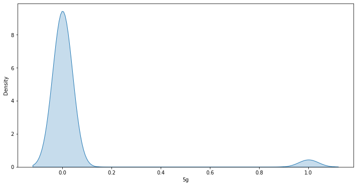

```python
plt.figure(figsize=(12, 6))
sns.kdeplot(data = df, x = '5g', shade = 'fill')
```

**Converted the categorical 5g variable to numerical.**

**Perform feature engineering on the os field.**

**Perform one-hot encoding on os.**

```python
df.reset_index(inplace = True, drop = True)
```

```python
df['os'].unique()
```

```
array(['Android', 'Others', 'iOS', 'Windows'], dtype=object)
```

```python
from sklearn.preprocessing import OneHotEncoder
```

```python
encoder = OneHotEncoder()
```

```python
encoded_os = encoder.fit_transform(df[['os']]).toarray()
```

```python
encoder_df = pd.DataFrame(encoded_os, columns = ['is_Android', 'is_Others', 'is_iOS', 'is_Windows'])
```

```python
encoder_df
```

|  | is_Android | is_Others | is_iOS | is_Windows |
| --- | --- | --- | --- | --- |
| 0 | 1.0 | 0.0 | 0.0 | 0.0 |
| 1 | 1.0 | 0.0 | 0.0 | 0.0 |
| 2 | 1.0 | 0.0 | 0.0 | 0.0 |
| 3 | 1.0 | 0.0 | 0.0 | 0.0 |
| 4 | 1.0 | 0.0 | 0.0 | 0.0 |
| ... | ... | ... | ... | ... |
| 3427 | 1.0 | 0.0 | 0.0 | 0.0 |
| 3428 | 1.0 | 0.0 | 0.0 | 0.0 |
| 3429 | 1.0 | 0.0 | 0.0 | 0.0 |
| 3430 | 1.0 | 0.0 | 0.0 | 0.0 |
| 3431 | 1.0 | 0.0 | 0.0 | 0.0 |

3432 rows × 4 columns

```python
df = df.join(encoder_df)
df.drop('os', axis = 1, inplace = True)
```

**Perform feature engineering on the brand field.**

**Perform one-hot encoding on brand name field.**

```python
df['brand_name'].nunique()
```

```
34
```

```python
encoder = OneHotEncoder()
```

```python
encoded_brand = encoder.fit_transform(df[['brand_name']]).toarray()
```

```python
unique_brands = list(df['brand_name'].unique())
```

```python
print(unique_brands)
```

```
['Honor', 'Others', 'HTC', 'Huawei', 'Infinix', 'Lava', 'Lenovo', 'LG', 'Meizu', 'Micromax', 'Motorola', 'Nokia', 'OnePlus', 'Oppo', 'Realme', 'Samsung', 'Vivo', 'Xiaomi', 'ZTE', 'Apple', 'Asus', 'Coolpad', 'Acer', 'Alcatel', 'BlackBerry', 'Celkon', 'Gionee', 'Google', 'Karbonn', 'Microsoft', 'Panas…
```

```python
encoder_df = pd.DataFrame(encoded_brand, columns = unique_brands)
```

```python
encoder_df
```

|  | Honor | Others | HTC | Huawei | Infinix | Lava | Lenovo | LG | Meizu | Micromax | ... | BlackBerry | Celkon | Gionee | Google | Karbonn | Microsoft | Panasonic | Sony | Spice | XOLO |
| --- | --- | --- | --- | --- | --- | --- | --- | --- | --- | --- | --- | --- | --- | --- | --- | --- | --- | --- | --- | --- | --- |
| 0 | 0.0 | 0.0 | 0.0 | 0.0 | 0.0 | 0.0 | 0.0 | 0.0 | 0.0 | 0.0 | ... | 0.0 | 0.0 | 0.0 | 0.0 | 0.0 | 0.0 | 0.0 | 0.0 | 0.0 | 0.0 |
| 1 | 0.0 | 0.0 | 0.0 | 0.0 | 0.0 | 0.0 | 0.0 | 0.0 | 0.0 | 0.0 | ... | 0.0 | 0.0 | 0.0 | 0.0 | 0.0 | 0.0 | 0.0 | 0.0 | 0.0 | 0.0 |
| 2 | 0.0 | 0.0 | 0.0 | 0.0 | 0.0 | 0.0 | 0.0 | 0.0 | 0.0 | 0.0 | ... | 0.0 | 0.0 | 0.0 | 0.0 | 0.0 | 0.0 | 0.0 | 0.0 | 0.0 | 0.0 |
| 3 | 0.0 | 0.0 | 0.0 | 0.0 | 0.0 | 0.0 | 0.0 | 0.0 | 0.0 | 0.0 | ... | 0.0 | 0.0 | 0.0 | 0.0 | 0.0 | 0.0 | 0.0 | 0.0 | 0.0 | 0.0 |
| 4 | 0.0 | 0.0 | 0.0 | 0.0 | 0.0 | 0.0 | 0.0 | 0.0 | 0.0 | 0.0 | ... | 0.0 | 0.0 | 0.0 | 0.0 | 0.0 | 0.0 | 0.0 | 0.0 | 0.0 | 0.0 |
| ... | ... | ... | ... | ... | ... | ... | ... | ... | ... | ... | ... | ... | ... | ... | ... | ... | ... | ... | ... | ... | ... |
| 3427 | 0.0 | 0.0 | 0.0 | 1.0 | 0.0 | 0.0 | 0.0 | 0.0 | 0.0 | 0.0 | ... | 0.0 | 0.0 | 0.0 | 0.0 | 0.0 | 0.0 | 0.0 | 0.0 | 0.0 | 0.0 |
| 3428 | 0.0 | 0.0 | 0.0 | 1.0 | 0.0 | 0.0 | 0.0 | 0.0 | 0.0 | 0.0 | ... | 0.0 | 0.0 | 0.0 | 0.0 | 0.0 | 0.0 | 0.0 | 0.0 | 0.0 | 0.0 |
| 3429 | 0.0 | 1.0 | 0.0 | 0.0 | 0.0 | 0.0 | 0.0 | 0.0 | 0.0 | 0.0 | ... | 0.0 | 0.0 | 0.0 | 0.0 | 0.0 | 0.0 | 0.0 | 0.0 | 0.0 | 0.0 |
| 3430 | 0.0 | 1.0 | 0.0 | 0.0 | 0.0 | 0.0 | 0.0 | 0.0 | 0.0 | 0.0 | ... | 0.0 | 0.0 | 0.0 | 0.0 | 0.0 | 0.0 | 0.0 | 0.0 | 0.0 | 0.0 |
| 3431 | 0.0 | 1.0 | 0.0 | 0.0 | 0.0 | 0.0 | 0.0 | 0.0 | 0.0 | 0.0 | ... | 0.0 | 0.0 | 0.0 | 0.0 | 0.0 | 0.0 | 0.0 | 0.0 | 0.0 | 0.0 |

3432 rows × 34 columns

```python
df = df.join(encoder_df)
df.drop('brand_name', axis = 1, inplace = True)
```

## EDA

- It is a good idea to explore the data once again after manipulating it.

**Calculate the correlation coefficients.**

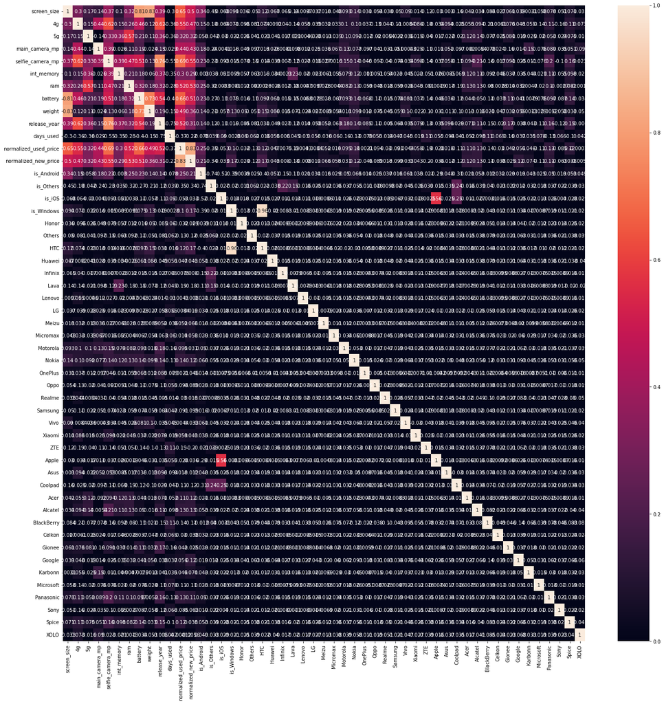

```python
plt.figure(figsize=(24, 24))
ax = sns.heatmap(data = df.corr(), vmin = 0, vmax = 1, annot = True)
```

**Feature transformations did not make a significant impact on the correlations of the variables.**

**Calculate the impurity of the dataset.**

**Entropy impurity**

```python
def compute_impurity(feature, impurity_criterion):
    probs = feature.value_counts(normalize = True)
    if impurity_criterion == 'entropy':
        impurity = -1 * np.sum(np.log2(probs) * probs)
    elif impurity_criterion == 'gini':
        impurity = 1 - np.sum(np.square(probs))
    return(impurity)
```

```python
impurity_list = []
for column in df.columns:
    impurity = compute_impurity(df[column], 'entropy')
    impurity_list.append([column, impurity])
impurity_array = np.array(impurity_list, dtype = str)
impurity_df = pd.DataFrame(impurity_array, columns = ['feature', 'impurity'])
impurity_df['impurity'] = impurity_df['impurity'].astype(float)
impurity_df = impurity_df.sort_values(by = ['impurity'], axis = 0, inplace = False)
print(impurity_df)
```

```
                  feature   impurity
29                OnePlus   0.028740
25                  Meizu   0.035926
36                  Apple   0.053790
23                 Lenovo   0.055920
21                Infinix   0.055920
39                   Acer   0.055920
30                   Oppo   0.070332
46              Microsoft   0.072328
22                   Lava   0.078232
16             is_Windows   0.084021
32                Samsung   0.084021
19                    HTC   0.089703
43                 Gionee   0.093437
48                   Sony   0.095287
```

[output cut: 37 more lines]

**Entropy impurity is a measure of disorder in the dataset.**  
**A lower entropy impurity value signifies a low degree of disorder.**  
**A high entropy impurity value signifies a high degree of disorder.**

```python
impurity_list = []
for column in df.columns:
    impurity = compute_impurity(df[column], 'gini')
    impurity_list.append([column, impurity])
impurity_array = np.array(impurity_list, dtype = str)
impurity_df = pd.DataFrame(impurity_array, columns = ['feature', 'impurity'])
impurity_df['impurity'] = impurity_df['impurity'].astype(float)
impurity_df = impurity_df.sort_values(by = ['impurity'], axis = 0, inplace = False)
print(impurity_df)
```

```
                  feature  impurity
29                OnePlus  0.005811
25                  Meizu  0.007547
36                  Apple  0.012163
23                 Lenovo  0.012738
21                Infinix  0.012738
39                   Acer  0.012738
30                   Oppo  0.016757
46              Microsoft  0.017330
22                   Lava  0.019046
16             is_Windows  0.020759
32                Samsung  0.020759
19                    HTC  0.022469
43                 Gionee  0.023607
48                   Sony  0.024176
```

[output cut: 37 more lines]

**Gini impurity is a measure of disorder in the dataset.**  
**A lower gini impurity value signifies a low degree of disorder.**  
**A high gini impurity value signifies a high degree of disorder.**

**Calculate mutual information**

```python
from pandas.api.types import is_numeric_dtype
```

```python
from sklearn.feature_selection import mutual_info_regression

def information_gain(
    df,
    labels : str,
    predictors : list,
    rdm_seed : int = 1234
) -> any:
    '''
    information_gain():
        Get most important features based on the value of information gain for categorical target variable.

        Parameters
        ----------
        df : pd.DataFrame, required
            Input dataframe containing all features
        predictors : list of str, required
            List of predictor features
        labels : list, required
            Target feature
        rdm_seed : random seed, not required
            Random seed used for reproducibility

        Returns
        ------
        important_features : pd.Dataframe
            Dataframe containing feature name and information gain value
    '''
    df_predictors = df[predictors]
    df_target = df[labels]

    importances = mutual_info_regression(df_predictors, df_target, random_state = rdm_seed, discrete_features = True)
    high_score_features = []
    for score, f_name in sorted(zip(importances, df_predictors.columns), reverse = True):
        high_score_features.append({'Feature': f_name, 'Score': score})

    df_important_features = pd.DataFrame(high_score_features)
    return df_important_features
```

```python
target = 'normalized_used_price'
features = [
    'screen_size',
    'main_camera_mp',
    'selfie_camera_mp',
    'int_memory',
    'ram',
    'battery',
    'weight',
    'release_year',
    'days_used',
    'normalized_new_price',
    'normalized_used_price'
]

df_mutual_information = information_gain(
    df[features],
    target,
    features[:-1],
    1234
)
```

```python
print(df_mutual_information)
```

```
                Feature     Score
0  normalized_new_price  0.678665
1           screen_size  0.584643
2               battery  0.524674
3      selfie_camera_mp  0.430840
4        main_camera_mp  0.381833
5                weight  0.368972
6            int_memory  0.360833
7                   ram  0.213735
8          release_year  0.206363
9             days_used  0.081125
```

**Normalized_new_price shares a high degree of information with the target.**  
**screen_size and battery are also highly significant predictors.**

**Calculate variance inflation factor.**

```python
from statsmodels.stats.outliers_influence import variance_inflation_factor
```

```python
features = [
    'screen_size',
    'main_camera_mp',
    'selfie_camera_mp',
    'int_memory',
    'ram',
    'battery',
    'weight',
    'release_year',
    'days_used',
    'normalized_new_price',
]
```

```python
df_vif = df.copy()[features]
```

```python
vif = [
    [val, variance_inflation_factor(df_vif.values, i)]
    for i, val
    in zip(np.arange(0, len(df_vif.columns)), df_vif.columns.values)
]
```

```python
vif_score_df = pd.DataFrame(vif, columns = ['Feature', 'VIF']).sort_values(by = 'VIF')
```

```python
print(vif_score_df)
```

```
                Feature         VIF
7          release_year   11.349729
8             days_used   13.970092
2      selfie_camera_mp   20.848750
9  normalized_new_price   28.632727
4                   ram   30.991252
1        main_camera_mp   31.961872
3            int_memory   52.794728
0           screen_size   56.762034
5               battery   75.257121
6                weight  108.359530
```

**Variance inflation factor is not promising here. There is a dangerously high degree of multicollinearity in the dataset.**

**Get the variance inflation factor of the features selected from the correlation matrix.**

```python
features = [
    'screen_size',
    'main_camera_mp',
    'selfie_camera_mp',
    'int_memory',
    'ram',
    'release_year',
    'normalized_new_price',
]
```

```python
df_vif = df.copy()[features]
```

```python
vif = [
    [val, variance_inflation_factor(df_vif.values, i)]
    for i, val
    in zip(np.arange(0, len(df_vif.columns)), df_vif.columns.values)
]
```

```python
vif_score_df = pd.DataFrame(vif, columns = ['Feature', 'VIF']).sort_values(by = 'VIF')
```

```python
print(vif_score_df)
```

```
                Feature        VIF
5          release_year   7.346245
0           screen_size  16.401509
2      selfie_camera_mp  19.312800
1        main_camera_mp  25.611795
6  normalized_new_price  27.960667
4                   ram  30.659256
3            int_memory  34.433356
```

**The variance inflation factor of the selected features is much better, but any value above 10 is undesirable.**

**Get correlations of remaining features.**

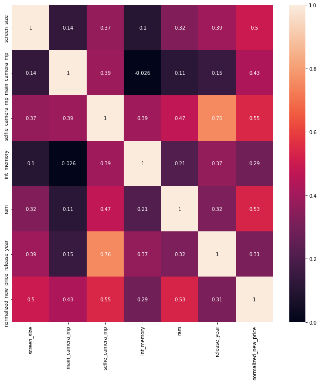

```python
plt.figure(figsize=(12, 12))
ax = sns.heatmap(data = df_vif.corr(), vmin = 0, vmax = 1, annot = True)
```

## Building a Linear Regression model

```python
from sklearn.model_selection import train_test_split
from sklearn.metrics import mean_absolute_error, mean_squared_error, r2_score
```

```python
def adj_r2_score(predictors, targets, predictions):
    r2 = r2_score(targets, predictions)
    n = predictors.shape[0]
    k = predictors.shape[1]
    return 1 - ((1 - r2) * (n - 1) / (n - k - 1))

def mape_score(targets, predictions):
    return np.mean(np.abs(targets - predictions) / targets) * 100

def model_performance_regression(model, predictors, target):
    pred = model.predict(predictors)

    r2 = r2_score(target, pred)
    adjr2 = adj_r2_score(predictors, target, pred)
    rmse = np.sqrt(mean_squared_error(target, pred))
    mae = mean_absolute_error(target, pred)
    mape = mape_score(target, pred)

    df_perf = pd.DataFrame(
        {
            "RMSE": rmse,
            "MAE": mae,
            "R-squared": r2,
            "Adj. R-squared": adjr2,
            "MAPE": mape,
        },
        index = [0],
    )

    return df_perf
```

**Get the training/testing data.**

```python
X = df.copy().drop(['normalized_used_price'], axis = 1, inplace = False)
Y = df['normalized_used_price']
```

**Split the data into 70:30 data for testing/training data**

```python
x_train, x_test, y_train, y_test = train_test_split(X, Y, test_size = 0.3, random_state = 1)
```

```python
print(fr'Rows in training data = {x_train.shape[0]}')
print(fr'Rows in testing data = {x_test.shape[0]}')
```

```
Rows in training data = 2402
Rows in testing data = 1030
```

```python
import statsmodels.api as sm
```

**Training the model**

```python
olsmodel = sm.OLS(y_train, x_train).fit()
print(olsmodel.summary())
```

```
                              OLS Regression Results
=================================================================================
Dep. Variable:     normalized_used_price   R-squared:                       0.847
Model:                               OLS   Adj. R-squared:                  0.844
Method:                    Least Squares   F-statistic:                     271.9
Date:                   Fri, 13 May 2022   Prob (F-statistic):               0.00
Time:                           20:59:16   Log-Likelihood:                 118.65
No. Observations:                   2402   AIC:                            -139.3
Df Residuals:                       2353   BIC:                             144.1
Df Model:                             48
Covariance Type:               nonrobust
========================================================================================
                           coef    std err          t      P>|t|      [0.025      0.975]
----------------------------------------------------------------------------------------
screen_size              0.5514      0.085      6.506      0.000       0.385       0.718
4g                       0.0064      0.016      0.391      0.696      -0.026       0.038
5g                       0.0061      0.031      0.195      0.846      -0.055       0.068
main_camera_mp           0.6906      0.066     10.489      0.000       0.562       0.820
selfie_camera_mp         0.5495      0.045     12.097      0.000       0.460       0.639
int_memory               0.2385      0.101      2.353      0.019       0.040       0.437
ram                      0.3095      0.063      4.880      0.000       0.185       0.434
battery                 -0.0785      0.082     -0.958      0.338      -0.239       0.082
weight                   0.9771      0.108      9.088      0.000       0.766       1.188
release_year             0.1388      0.034      4.053      0.000       0.072       0.206
days_used                0.0343      0.031      1.118      0.264      -0.026       0.094
normalized_new_price     2.0814      0.063     33.290      0.000       1.959       2.204
is_Android               1.5313      0.070     22.018      0.000       1.395       1.668
is_Others                1.5658      0.072     21.746      0.000       1.425       1.707
is_iOS                   1.5014      0.083     18.130      0.000       1.339       1.664
is_Windows               1.4788      0.150      9.850      0.000       1.184       1.773
Honor                    0.1582      0.040      3.928      0.000       0.079       0.237
Others                   0.1718      0.027      6.268      0.000       0.118       0.226
HTC                      0.1588      0.136      1.171      0.242      -0.107       0.425
Huawei                   0.2002      0.028      7.084      0.000       0.145       0.256
Infinix                  0.1799      0.057      3.182      0.001       0.069       0.291
Lava                    -0.0673      0.057     -1.186      0.236      -0.179       0.044
Lenovo                   0.2035      0.058      3.486      0.000       0.089       0.318
LG                       0.1335      0.042      3.193      0.001       0.051       0.215
Meizu                    0.1043      0.087      1.196      0.232      -0.067       0.275
Micromax                 0.1887      0.030      6.333      0.000       0.130       0.247
```

[output cut: 20 more lines]

```
Panasonic                0.1582      0.029      5.488      0.000       0.102       0.215
Sony                     0.1243      0.046      2.688      0.007       0.034       0.215
Spice                    0.2584      0.027      9.411      0.000       0.205       0.312
XOLO                     0.1695      0.027      6.252      0.000       0.116       0.223
==============================================================================
Omnibus:                      167.775   Durbin-Watson:                   2.047
Prob(Omnibus):                  0.000   Jarque-Bera (JB):              389.450
Skew:                          -0.427   Prob(JB):                     2.70e-85
Kurtosis:                       4.778   Cond. No.                     2.25e+15
==============================================================================

Notes:
[1] Standard Errors assume that the covariance matrix of the errors is correctly specified.
[2] The smallest eigenvalue is 1.91e-27. This might indicate that there are
strong multicollinearity problems or that the design matrix is singular.
```

**0.05 is the established significance level for the dataset.**  
**4g, 5g, battery, days_used, HTC, and Meizu do not achieve the established significance level and thus are not statistically significant.**

**screen_size, main_camera_mp, selfie_camera_mp, normalized_new_price, is_Android, is_Others, is_iOS, and is_Windows all have large coefficients**  
**That means they have a strong predictive capability in the model.**

**Let's remove the less statistically signifcant features from the model.**

```python
print('''
Training Error
''')
olsmodel_train_perf = model_performance_regression(olsmodel, x_train, y_train)
olsmodel_train_perf
```

```
Training Error
```

|  | RMSE | MAE | R-squared | Adj. R-squared | MAPE |
| --- | --- | --- | --- | --- | --- |
| 0 | 0.230308 | 0.179311 | 0.847247 | 0.843998 | 4.295297 |

**Get the training/testing data.**

```python
X = df.copy().drop(['normalized_used_price', '4g', '5g', 'battery', 'days_used', 'HTC', 'Meizu'], axis = 1, inplace = False)
Y = df['normalized_used_price']
```

**Split the data into 70:30 data for testing/training data**

```python
x_train, x_test, y_train, y_test = train_test_split(X, Y, test_size = 0.3, random_state = 1)
```

```python
print(fr'Rows in training data = {x_train.shape[0]}')
print(fr'Rows in testing data = {x_test.shape[0]}')
```

```
Rows in training data = 2402
Rows in testing data = 1030
```

```python
olsmodel = sm.OLS(y_train, x_train).fit()
print(olsmodel.summary())
```

```
                              OLS Regression Results
=================================================================================
Dep. Variable:     normalized_used_price   R-squared:                       0.847
Model:                               OLS   Adj. R-squared:                  0.844
Method:                    Least Squares   F-statistic:                     303.8
Date:                   Fri, 13 May 2022   Prob (F-statistic):               0.00
Time:                           20:59:17   Log-Likelihood:                 117.39
No. Observations:                   2402   AIC:                            -146.8
Df Residuals:                       2358   BIC:                             107.7
Df Model:                             43
Covariance Type:               nonrobust
========================================================================================
                           coef    std err          t      P>|t|      [0.025      0.975]
----------------------------------------------------------------------------------------
screen_size              0.5248      0.080      6.525      0.000       0.367       0.683
main_camera_mp           0.7009      0.061     11.527      0.000       0.582       0.820
selfie_camera_mp         0.5459      0.045     12.131      0.000       0.458       0.634
int_memory               0.2308      0.100      2.320      0.020       0.036       0.426
ram                      0.3101      0.057      5.394      0.000       0.197       0.423
weight                   0.9449      0.100      9.413      0.000       0.748       1.142
release_year             0.1188      0.027      4.464      0.000       0.067       0.171
normalized_new_price     2.0800      0.060     34.694      0.000       1.962       2.198
is_Android               1.6696      0.106     15.785      0.000       1.462       1.877
is_Others                1.7016      0.105     16.168      0.000       1.495       1.908
is_iOS                   1.6425      0.116     14.214      0.000       1.416       1.869
is_Windows               1.6616      0.083     20.097      0.000       1.499       1.824
Honor                    0.0435      0.085      0.512      0.609      -0.123       0.210
Others                   0.0577      0.080      0.725      0.468      -0.098       0.214
Huawei                   0.0836      0.079      1.053      0.293      -0.072       0.239
Infinix                  0.0614      0.093      0.661      0.509      -0.121       0.243
Lava                    -0.1834      0.095     -1.940      0.053      -0.369       0.002
Lenovo                   0.0925      0.096      0.968      0.333      -0.095       0.280
LG                       0.0158      0.086      0.184      0.854      -0.153       0.185
Micromax                 0.0741      0.081      0.920      0.358      -0.084       0.232
Motorola                 0.0651      0.080      0.815      0.415      -0.092       0.222
Nokia                    0.0178      0.077      0.230      0.818      -0.134       0.169
OnePlus                  0.2637      0.110      2.399      0.017       0.048       0.479
Oppo                     0.0768      0.093      0.829      0.407      -0.105       0.258
Realme                   0.0102      0.078      0.130      0.896      -0.143       0.163
Samsung                  0.0272      0.091      0.298      0.766      -0.152       0.206
```

[output cut: 12 more lines]

```
Karbonn                  0.0692      0.082      0.848      0.397      -0.091       0.229
Microsoft               -0.0179      0.092     -0.194      0.846      -0.198       0.162
Panasonic                0.0403      0.080      0.506      0.613      -0.116       0.196
Sony                     0.0063      0.089      0.071      0.943      -0.168       0.181
Spice                    0.1404      0.079      1.777      0.076      -0.015       0.295
XOLO                     0.0549      0.079      0.692      0.489      -0.101       0.210
==============================================================================
Omnibus:                      169.810   Durbin-Watson:                   2.045
Prob(Omnibus):                  0.000   Jarque-Bera (JB):              394.226
Skew:                          -0.432   Prob(JB):                     2.48e-86
Kurtosis:                       4.787   Cond. No.                         162.
==============================================================================

Notes:
[1] Standard Errors assume that the covariance matrix of the errors is correctly specified.
```

```python
print('''
Training Error
''')
olsmodel_train_perf = model_performance_regression(olsmodel, x_train, y_train)
olsmodel_train_perf
```

```
Training Error
```

|  | RMSE | MAE | R-squared | Adj. R-squared | MAPE |
| --- | --- | --- | --- | --- | --- |
| 0 | 0.23043 | 0.17931 | 0.847086 | 0.844231 | 4.29682 |

**Removing the statistically insignificent features did not degrade the performance of the model.**  
**The r-squared value slightly decreased but the adjusted r-squared value increased.**

## Model performance evaluation

```python
print('''
Training Error
''')
olsmodel_train_perf = model_performance_regression(olsmodel, x_train, y_train)
olsmodel_train_perf
```

```
Training Error
```

|  | RMSE | MAE | R-squared | Adj. R-squared | MAPE |
| --- | --- | --- | --- | --- | --- |
| 0 | 0.23043 | 0.17931 | 0.847086 | 0.844231 | 4.29682 |

```python
print('''
Test Error
''')
olsmodel_test_perf = model_performance_regression(olsmodel, x_test, y_test)
olsmodel_test_perf
```

```
Test Error
```

|  | RMSE | MAE | R-squared | Adj. R-squared | MAPE |
| --- | --- | --- | --- | --- | --- |
| 0 | 0.231079 | 0.179987 | 0.837714 | 0.830465 | 4.326414 |

**An r-squared value of 0.85 means that the model is able to explain 85% of the variation in the data.**  
**The RMSE and MAE are similar, which means that the model is not overfitting.**  
**The MAPE means the model can predict within 4.3% of the used phone price.**  
**From this information, we can say that the model is a good predictor of the target and has strong explainability.**

## Checking Linear Regression Assumptions

- In order to make statistical inferences from a linear regression model, it is important to ensure that the assumptions of linear regression are satisfied.

**These are the assumptions of the ols model that we need to satisfy**  
**1. Linearity of variables**  
**2. Independence of error terms**  
**3. Normality of error terms**  
**4. No Heteroscedasticity**

**1. Linearity of variables**

```python
df_pred = pd.DataFrame()

df_pred["Actual Values"] = y_train
df_pred["Fitted Values"] = olsmodel.fittedvalues
df_pred["Residuals"] = olsmodel.resid

df_pred.head()
```

|  | Actual Values | Fitted Values | Residuals |
| --- | --- | --- | --- |
| 683 | 4.824225 | 4.715082 | 0.109143 |
| 3364 | 4.145354 | 4.461329 | -0.315974 |
| 2313 | 3.774139 | 3.660646 | 0.113493 |
| 1569 | 4.433907 | 4.772872 | -0.338965 |
| 1169 | 4.553772 | 4.516158 | 0.037614 |

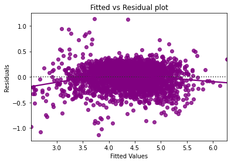

```python
sns.residplot(
    data=df_pred, x="Fitted Values", y="Residuals", color="purple", lowess=True
)
plt.xlabel("Fitted Values")
plt.ylabel("Residuals")
plt.title("Fitted vs Residual plot")
plt.show()
```

**Since there is no pattern in the plot above, there isn't some non-linearity that the model fails to account for.**  
**This also satisfies the test for independence.**

**3. Normality of error terms**

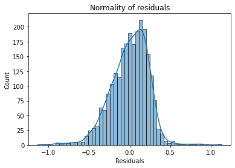

```python
sns.histplot(data=df_pred, x="Residuals", kde=True)
plt.title("Normality of residuals")
plt.show()
```

**This histogram of residuals has a bell shape. It can be said that it is roughly normally distributed.**

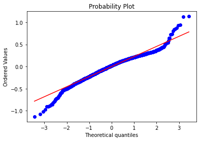

```python
import pylab
import scipy.stats as stats

stats.probplot(df_pred["Residuals"], dist="norm", plot=pylab)
plt.show()
```

**The residuals follow a slightly curved line aside from the tails. It is apparant from the Q-Q plot that residuals are skewed in one direction causing kurtosis in the distribution.**

```python
stats.shapiro(df_pred["Residuals"])
```

```
ShapiroResult(statistic=0.971601128578186, pvalue=2.019629724104624e-21)
```

**Since the p-value is less than 0.05, that means the residuals fail the test of normality.**  
**However, we can make the assertion that this distribution is close to normal.**

**4. No Heteroscedasticity**

```python
import statsmodels.stats.api as sms
from statsmodels.compat import lzip

name = ["F statistic", "p-value"]
test = sms.het_goldfeldquandt(df_pred["Residuals"], x_train)
lzip(name, test)
```

```
[('F statistic', 1.0092713505409279), ('p-value', 0.4376537691460938)]
```

**Since the p-value for this test is 0.43 which is greater than 0.05, that means the test for homoscedasticity is satisfied.**

## Final Model Summary

```python
pred = olsmodel.predict(x_test)

df_pred_test = pd.DataFrame({"Actual": y_test, "Predicted": pred})
df_pred_test.sample(10, random_state=1)
```

|  | Actual | Predicted |
| --- | --- | --- |
| 984 | 4.204095 | 4.176370 |
| 1230 | 4.061649 | 4.156680 |
| 3182 | 5.452411 | 5.397856 |
| 2396 | 4.338336 | 4.348803 |
| 2008 | 4.251206 | 3.999701 |
| 1373 | 4.898437 | 4.871251 |
| 1896 | 2.753024 | 2.730041 |
| 1816 | 4.104130 | 4.228986 |
| 1728 | 4.415945 | 4.425950 |
| 1872 | 4.021953 | 3.850534 |

**The model returns decent results, and the Actual and Predicted values are similar.**

## Actionable Insights and Recommendations

**1. Microsoft and Lava phones are worth less used than other brands of phones.**  
**2. Operating systems tend to not make a difference towards a used phone's price.**  
**3. The new price of the phone is the strongest indicator of used phone price.**  
**4. Weight, main camera megapixels, selfie camera megapixels, and screen size are highly predictive of used phone price.**  
**5. Surprisingly, release year is not highly predictive of used phone price. This goes against the assumption that newer phones would be more valuable.**